# ESS 330 lab 6

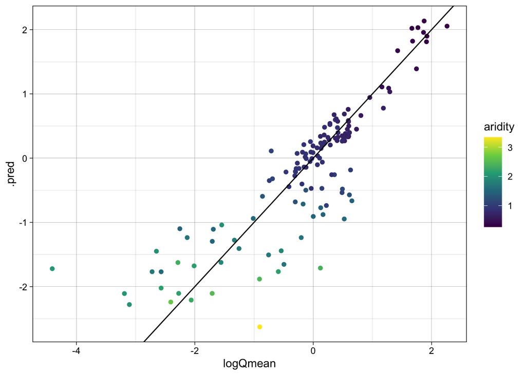

```r
ggplot(lm_data, aes(x = logQmean, y = .pred, colour = aridity)) +
  scale_color_viridis_c() +
  geom_point() +
  geom_abline() +
  theme_linedraw()
```

```r
library(baguette)

rf_model <- rand_forest() %>%
  set_engine("ranger", importance = "impurity") %>%
  set_mode("regression")

rf_wf <- workflow() %>%
  # Add the recipe
  add_recipe(rec) %>%
  # Add the model
  add_model(rf_model) %>%
  # Fit the model
  fit(data = camels_train)

rf_data <- augment(rf_wf, new_data = camels_test)
dim(rf_data)
```

```
[1] 135  60
```

```r
metrics(rf_data, truth = logQmean, estimate = .pred)
```

```
# A tibble: 3 × 3
  .metric .estimator .estimate
  <chr>   <chr>          <dbl>
1 rmse    standard       0.592
2 rsq     standard       0.736
3 mae     standard       0.367
```

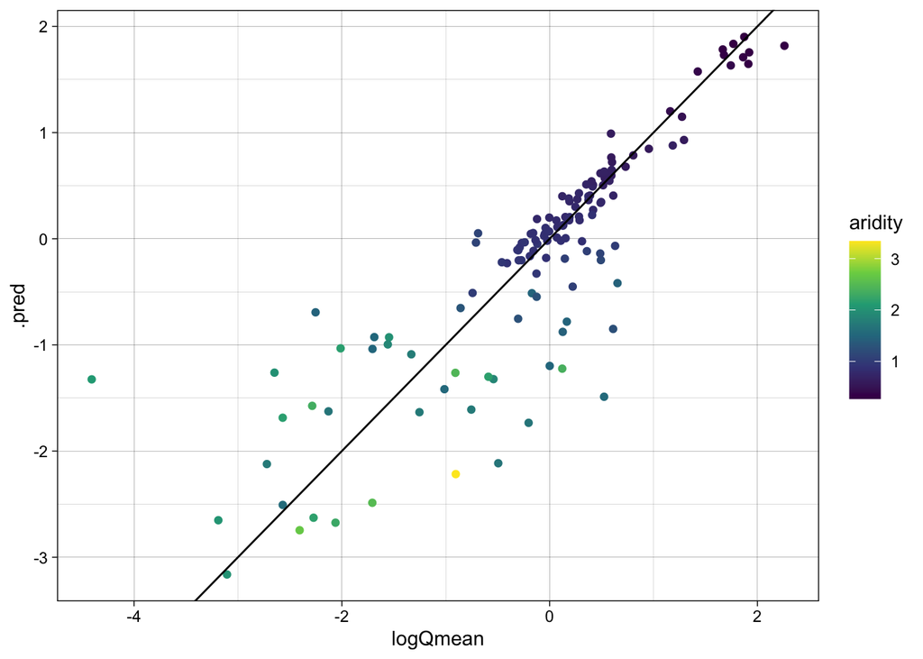

```r
ggplot(rf_data, aes(x = logQmean, y = .pred, colour = aridity)) +
  scale_color_viridis_c() +
  geom_point() +
  geom_abline() +
  theme_linedraw()
```

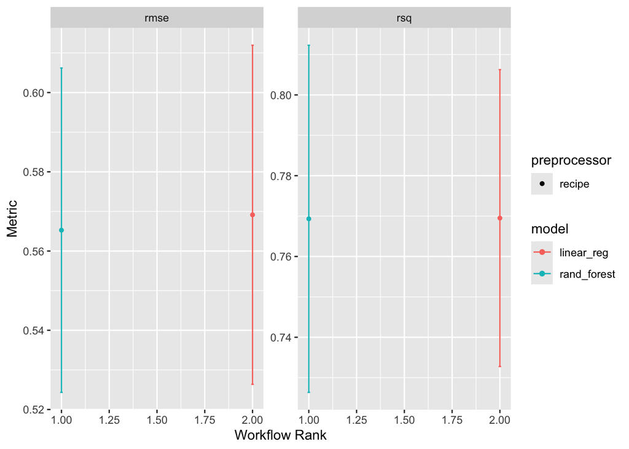

```r
wf <- workflow_set(list(rec), list(lm_model, rf_model)) %>%
  workflow_map('fit_resamples', resamples = camels_cv)

autoplot(wf)
```

Demo –^

# Question 2

```r
map_1 <- ggplot(camels, aes(x = gauge_lon, y = gauge_lat)) +
  borders("state", colour = "gray50") +
  geom_point(aes(color = aridity)) +
  scale_color_gradient(low = "lightblue", high = "orange") +
  coord_fixed() +
  labs(title = "Aridity across the U.S",
       x = "Longitude", y = "Latitude", color = "Aridity (Priestley-Taylor formulation)") +
    ggthemes::theme_map() +
   theme(
    legend.position = "bottom",
    legend.direction = "horizontal")
```

```r
map_2 <- ggplot(camels, aes(x = gauge_lon, y = gauge_lat)) +
  borders("state", colour = "gray50") +
  geom_point(aes(color = p_mean)) +
  scale_color_gradient(low = "pink", high = "lightblue") +
  coord_fixed() +
  labs(title = "Mean Daily Preciptiation Across the U.S",
       x = "Longitude", y = "Latitude", color = "Mean Precipitation (mm/day)") +
    ggthemes::theme_map() +
   theme(
    legend.position = "bottom",
    legend.direction = "horizontal")
```

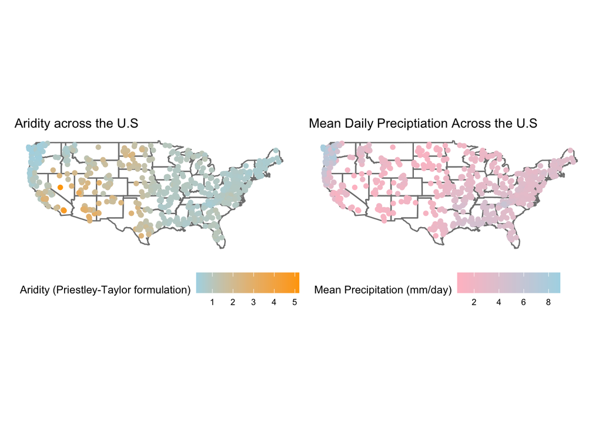

```r
library(patchwork)
map_1 + map_2
```

# Question 3

Define additional models

```r
# XGBoost
xgb_model <- boost_tree() %>%
  set_engine("xgboost") %>%
  set_mode("regression")

# Bagged MLP Neural Net
mlp_model <- bag_mlp() %>%
  set_engine("nnet") %>%
  set_mode("regression")
```

Create workflows

```r
# XGBoost Workflow
xgb_wf <- workflow() %>%
  add_recipe(rec) %>%
  add_model(xgb_model) %>%
  fit(data = camels_train)

# Bagged Neural Net Workflow
mlp_wf <- workflow() %>%
  add_recipe(rec) %>%
  add_model(mlp_model) %>%
  fit(data = camels_train)
```

Predictions

```r
# Predict and add to test set
lm_data <- camels_test %>%
  mutate(.pred = predict(lm_wf, .)$.pred)

rf_data <- camels_test %>%
  mutate(.pred = predict(rf_wf, .)$.pred)

xgb_data <- camels_test %>%
  mutate(.pred = predict(xgb_wf, .)$.pred)

mlp_data <- camels_test %>%
  mutate(.pred = predict(mlp_wf, .)$.pred)
```

Evaluate metrics

```r
model_metrics <- bind_rows(
  metrics(lm_data, truth = logQmean, estimate = .pred) %>% mutate(model = "Linear"),
  metrics(rf_data, truth = logQmean, estimate = .pred) %>% mutate(model = "Random Forest"),
  metrics(xgb_data, truth = logQmean, estimate = .pred) %>% mutate(model = "XGBoost"),
  metrics(mlp_data, truth = logQmean, estimate = .pred) %>% mutate(model = "Bagged MLP")
) %>%
  select(model, everything())
print(model_metrics)
```

```
# A tibble: 12 × 4
   model         .metric .estimator .estimate
   <chr>         <chr>   <chr>          <dbl>
 1 Linear        rmse    standard       0.583
 2 Linear        rsq     standard       0.742
 3 Linear        mae     standard       0.390
 4 Random Forest rmse    standard       0.592
 5 Random Forest rsq     standard       0.736
 6 Random Forest mae     standard       0.367
 7 XGBoost       rmse    standard       0.631
 8 XGBoost       rsq     standard       0.702
 9 XGBoost       mae     standard       0.397
10 Bagged MLP    rmse    standard       0.559
11 Bagged MLP    rsq     standard       0.761
12 Bagged MLP    mae     standard       0.348
```

Visualize XGB

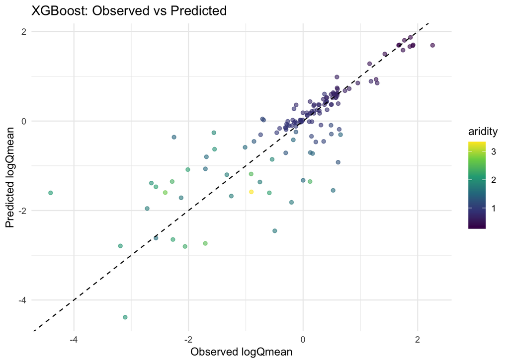

```r
xgb_preds <- camels_test %>%
  mutate(.pred = predict(xgb_wf, .)$.pred)

ggplot(xgb_preds, aes(x = logQmean, y = .pred, color = aridity)) +
  scale_color_viridis_c() +
  geom_point(alpha = 0.6) +
  geom_abline(linetype = "dashed") +
  theme_minimal() +
  labs(
    title = "XGBoost: Observed vs Predicted",
    x = "Observed logQmean",
    y = "Predicted logQmean"
  )
```

Visualize MLP

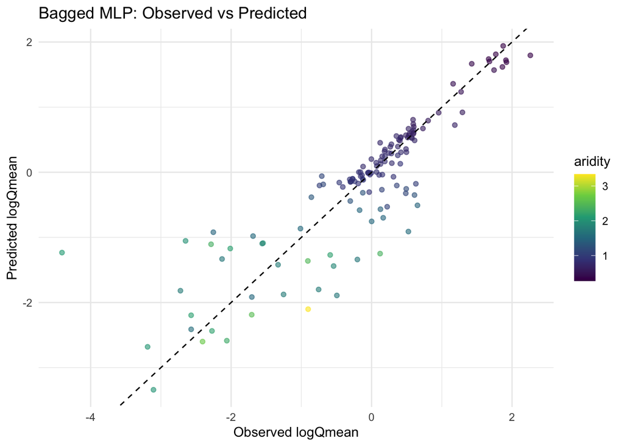

```r
mlp_preds <- camels_test %>%
  mutate(.pred = predict(mlp_wf, .)$.pred)

ggplot(mlp_preds, aes(x = logQmean, y = .pred, color = aridity)) +
  scale_color_viridis_c() +
  geom_point(alpha = 0.6) +
  geom_abline(linetype = "dashed") +
  theme_minimal() +
  labs(
    title = "Bagged MLP: Observed vs Predicted",
    x = "Observed logQmean",
    y = "Predicted logQmean"
  )
```

For modeling this data, I would chose the Bagged MLP model as it preforms the best. It has the lowest RMSE and MAE, which indicates better accuracy. It also has the highest R^2 which indicated better correlations.

# Question 4

```r
# Set seed for reproducibility
set.seed(1102)

#removing NAs
camels |>
  select(slope_mean, p_mean, logQmean) |>
  drop_na() |>
  cor()
```

```
           slope_mean    p_mean  logQmean
slope_mean  1.0000000 0.2602688 0.3687933
p_mean      0.2602688 1.0000000 0.8053056
logQmean    0.3687933 0.8053056 1.0000000
```

```r
# Initial train/test split
split <- initial_split(camels, prop = 0.75)
camels_train <- training(split)
camels_test  <- testing(split)

# Create 10-fold cross-validation
cv_folds <- vfold_cv(camels_train, v = 10)

# Defining my recipe
rec2 <- recipe(logQmean ~ p_mean + slope_mean  , data = camels_train) %>%
  step_log(all_predictors())%>%
  step_interact(terms = ~ p_mean:slope_mean) %>%
  step_naomit(all_predictors(), all_outcomes())
```

For this formula I chose slope_mean and p_mean. Slope_mean is the mean slope of the catchment. I assumed this would impact discharge because the water is more likely to run off and down the catchment due to gravity, and I suspect that all other variables held constant, and area with a greater slope would have greater daily discharge. I also chose p_mean which is mean daily precipitation, which would influence discharge because more water in the area means more area in the river/stream. I chose to add these together because greater values of each variable would compound into greater discharge.

```r
#Bake Data
baked_data2 <- prep(rec2, camels_train) %>%
  bake(new_data = NULL)

#linear model
lm_base2 <- lm(logQmean ~ p_mean * slope_mean, data = baked_data2)
summary(lm_base2)
```

```
Call:
lm(formula = logQmean ~ p_mean * slope_mean, data = baked_data2)

Residuals:
     Min       1Q   Median       3Q      Max
-2.59234 -0.26155  0.02523  0.25449  1.65766

Coefficients:
                  Estimate Std. Error t value Pr(>|t|)
(Intercept)       -4.77993    0.17535 -27.260   <2e-16 ***
p_mean             3.67249    0.15618  23.515   <2e-16 ***
slope_mean         0.62593    0.04691  13.344   <2e-16 ***
p_mean:slope_mean -0.37395    0.04010  -9.326   <2e-16 ***
---
Signif. codes:  0 '***' 0.001 '**' 0.01 '*' 0.05 '.' 0.1 ' ' 1

Residual standard error: 0.4877 on 498 degrees of freedom
Multiple R-squared:  0.8372,    Adjusted R-squared:  0.8362
F-statistic: 853.6 on 3 and 498 DF,  p-value: < 2.2e-16
```

I could not find variables with an R^2 >0.9, but this once is high and about the closest I found

Define Models

```r
xgb_model2 <- boost_tree() %>%
  set_engine("xgboost") %>%
  set_mode("regression")

rf_model2 <- rand_forest() %>%
  set_engine("ranger") %>%
  set_mode("regression")

lm_model2 <- linear_reg() %>%
  set_engine("lm")%>%
  set_mode("regression")
```

Creating workflow

```r
# Linear regression workflow

lm_workflow <- workflow() %>%
  add_recipe(rec2) %>%
  add_model(lm_model2)

# Random forest workflow
rf_workflow <- workflow() %>%
  add_recipe(rec2) %>%
  add_model(rf_model2)

# XGBoost workflow
xgb_workflow <- workflow() %>%
  add_recipe(rec2) %>%
  add_model(xgb_model2)
```

Fit to resamples

```r
# Fit linear model
lm_res <- fit_resamples(
  lm_workflow,
  resamples = cv_folds,
  control = control_resamples(save_pred = TRUE)
)

# Fit random forest
rf_res <- fit_resamples(
  rf_workflow,
  resamples = cv_folds,
  control = control_resamples(save_pred = TRUE)
)

# Fit XGBoost
xgb_res <- fit_resamples(
  xgb_workflow,
  resamples = cv_folds,
  control = control_resamples(save_pred = TRUE)
)
```

Create workflow set

```r
# Create a workflow set
model_set <- workflow_set(
  preproc = list(rec2 = rec2),
  models = list(
    linear_reg = lm_model2,
    random_forest = rf_model2,
    xgboost = xgb_model2
  )
)

# Tune all models in the workflow set
model_set_res <- model_set %>%
  workflow_map("tune_grid", resamples = cv_folds)
```

Rank results

```r
# Rank based on RMSE
rank_results(model_set_res, rank_metric = "rmse")
```

```
# A tibble: 6 × 9
  wflow_id          .config .metric  mean std_err     n preprocessor model  rank
  <chr>             <chr>   <chr>   <dbl>   <dbl> <int> <chr>        <chr> <int>
1 rec2_random_fore… Prepro… rmse    0.438  0.0239    10 recipe       rand…     1
2 rec2_random_fore… Prepro… rsq     0.875  0.0113    10 recipe       rand…     1
3 rec2_xgboost      Prepro… rmse    0.470  0.0237    10 recipe       boos…     2
4 rec2_xgboost      Prepro… rsq     0.861  0.0117    10 recipe       boos…     2
5 rec2_linear_reg   Prepro… rmse    0.485  0.0251    10 recipe       line…     3
6 rec2_linear_reg   Prepro… rsq     0.842  0.0116    10 recipe       line…     3
```

Plot results

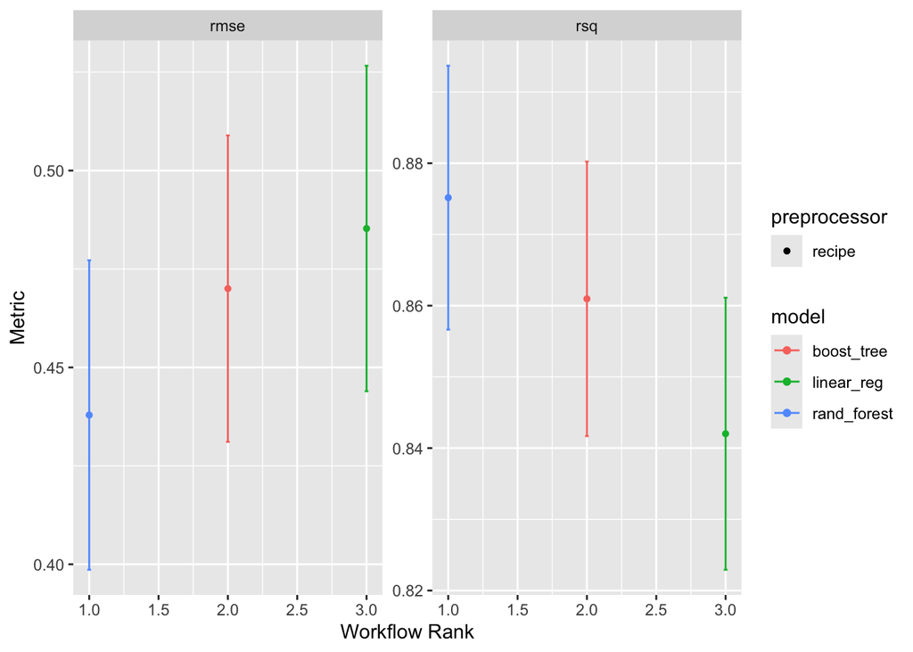

```r
autoplot(model_set_res)
```

The model that I think is best is the Random Forest, as it has the lowest RMSE, indicating best prediction accuracy on average. it also has the highest R^2 and a low standard error, which indicates that this model explains the most variance in streamflow, nad is also relatively stable across the 10 reseamples.

Extract and evaluate

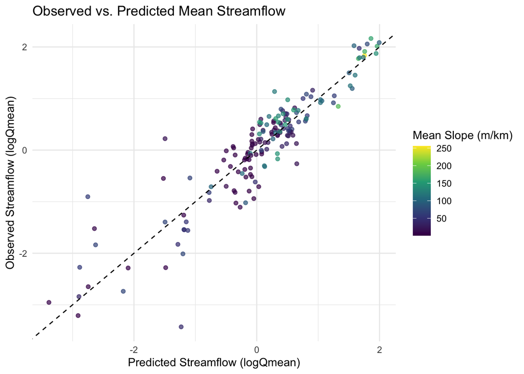

```r
final_rf_workflow <- workflow() %>%
  add_recipe(rec2) %>%
  add_model(rf_model2)

final_rf_fit <- final_rf_workflow %>%
  fit(data = camels_train)

rf_predictions <- augment(final_rf_fit, new_data = camels_test)

ggplot(rf_predictions, aes(x = .pred, y = logQmean)) +
  geom_point(aes(color = slope_mean ), alpha = 0.7) +
  geom_abline(slope = 1, intercept = 0, linetype = "dashed") +
  labs(
    title = "Observed vs. Predicted Mean Streamflow",
    x = "Predicted Streamflow (logQmean)",
    y = "Observed Streamflow (logQmean)",
    color = "Mean Slope (m/km)"
  ) +
  scale_color_viridis_c() +
  theme_minimal()
```

In these results I see that where the stream flow is low, it is harder to predict based on my defined variables. This makes sense because I know that when streams or areas are dry, any precipitation can cause them to become “flashy”. Where the stream flow is positive, the observed and predicted stream flow are much closer together and the fit seems good. I can also see that there is a good trend in slope and flow, where more slope creates more observed streamlow, as I predicted.